# 04-exercices-ARDl-cointégration

Author

Romain CAPLIEZ

# Exercice 1 : L’Hypothèse de Fisher et la Cointégration

**Données :**`intdef` du package `wooldridge`.

*Tester la relation de long terme entre le taux d’intérêt des bons du trésor à 3 mois (`i3`) et le taux d’inflation (`inf`). Selon l’effet Fisher, une augmentation de l’inflation devrait se traduire par une augmentation équivalente des taux d’intérêt nominaux à long terme (coefficient de 1).*

## Question 0

*Charger le setup de l’analyse*

## Question 1

*Importer les données `intdef`. Créer un nouvel objet TS contenant les variables `i3` et `inf`. Représenter graphiquement les deux séries sur le même graphique. Semblent-elles évoluer ensemble ?*

## Question 2

*Réaliser les tests de stationnarité sur les deux variables. Sont-elles intégrées du même ordre ? Peut-on réaliser la procédure d’Engle-Granger pour la cointégration ? Si oui tester la cointégration entre ces deux variables avec cette procédure. Estimer le modèle à correction d’erreur lié. Que peut-on en conclure ?*

## Question 3

*Estimer un modèle ARDL pour expliquer `i3` par `inf`. Quel sont les ordres choisi ? Pourquoi ?*

## Question 4

*Réaliser le test des bornes (Bounds Test) sur le modèle estimé. Peut-on conclure à l’existence d’une relation de cointégration entre les taux d’intérêt et l’inflation au seuil de 5% ? Au seuil de 1% ?*

## Question 5

*Si la cointégration est avérée, estimer les coefficients de long terme. Le coefficient associé à l’inflation est-il statistiquement différent de 1 ? L’hypothèse de Fisher est-elle validée sur cette période ?*

## Question 6

*Estimer le modèle à correction d’erreur (ECM) associé. Quelle est la vitesse d’ajustement vers l’équilibre de long terme ? Commentez son signe et sa significativité.*

## Question 7

*Représenter l’équation de long-terme de `i3` et la comparer aux données réelles. Que pouvez-vous en dire ?*

## Question 8

*Le modèle satisfait-il les hypothèses des MCO ? Si non comment pourriez-vous corriger cela ?*

# Exercice 2 : La courbe de Phillips

*Le trésor américain vous demande d’utiliser les données `phillips` du package `woolridge` afin de tester l’existence de la courbe de Phillips, c’est à dire l’existence d’une relation négative entre l’inflation et le chômage. Définissez une stratégie et une modélisation pour tester cette relation. Cette relation existe-t-elle à court- et long-terme ? Comment se situe l’inflation réelle par rapport à son niveau de long-terme ? Que pourriez-vous proposer au trésor américain pour améliorer l’analyse ?*

# Exercice 3 : Fertilité

*Vous venez de récupérer le script R d’un économètre senior qui a quitté le bureau. Il étudie la relation entre le taux de fertilité (`gfr`) et l’exonération fiscale personnelle réelle (`pe`) aux États-Unis sur la période 1913-1984. Expliquez et interprétez les différentes étapes. Que pouvez-vous conclure ? Quelles améliorations et suites pouvez-vous proposer ?*

```r
source(here::here("02-codes", "utils", "setup.R"))
```

```r
wooldridge::fertil3 |>
  str()
```

```
'data.frame':   72 obs. of  24 variables:
 $ gfr   : num  125 127 125 123 121 ...
 $ pe    : num  0 0 0 0 19.3 ...
 $ year  : int  1913 1914 1915 1916 1917 1918 1919 1920 1921 1922 ...
 $ t     : int  1 2 3 4 5 6 7 8 9 10 ...
 $ tsq   : int  1 4 9 16 25 36 49 64 81 100 ...
 $ pe_1  : num  NA 0 0 0 0 ...
 $ pe_2  : num  NA NA 0 0 0 ...
 $ pe_3  : num  NA NA NA 0 0 ...
 $ pe_4  : num  NA NA NA NA 0 ...
 $ pill  : int  0 0 0 0 0 0 0 0 0 0 ...
 $ ww2   : int  0 0 0 0 0 0 0 0 0 0 ...
 $ tcu   : num  1 8 27 64 125 216 343 512 729 1000 ...
 $ cgfr  : num  NA 1.9 -1.6 -1.6 -2.4 ...
 $ cpe   : num  NA 0 0 0 19.3 ...
 $ cpe_1 : num  NA NA 0 0 0 ...
 $ cpe_2 : num  NA NA NA 0 0 ...
 $ cpe_3 : num  NA NA NA NA 0 ...
 $ cpe_4 : num  NA NA NA NA NA ...
 $ gfr_1 : num  NA 125 127 125 123 ...
 $ cgfr_1: num  NA NA 1.9 -1.6 -1.6 ...
 $ cgfr_2: num  NA NA NA 1.9 -1.6 ...
 $ cgfr_3: num  NA NA NA NA 1.9 ...
 $ cgfr_4: num  NA NA NA NA NA ...
 $ gfr_2 : num  NA NA 125 127 125 ...
 - attr(*, "time.stamp")= chr "25 Jun 2011 23:03"
```

```r
df <-
  wooldridge::fertil3  |>
  as_tibble() |>
  mutate(
    year = lubridate::make_date(year)
  ) |>
  select(year, gfr, pe, pill, ww2) |>
  mutate(
    across(
      .cols = c(gfr, pe),
      .fns = \(var) log(var),
      .names = "log_{.col}"
    ),
    across(
      .cols = c(gfr, pe),
      .fns = \(var) log(var) - log(lag(var)),
      .names = "diff_log_{.col}"
    ),
    across(
      .cols = everything(),
      .fns = \(var) if_else(is.infinite(var), NA, var)
    )
  ) |>
  drop_na() |>
  print()
```

```
# A tibble: 67 × 9
   year         gfr    pe  pill   ww2 log_gfr log_pe diff_log_gfr diff_log_pe
   <date>     <dbl> <dbl> <int> <int>   <dbl>  <dbl>        <dbl>       <dbl>
 1 1918-01-01 120.   23.9     0     0    4.79   3.18     -0.00997      0.217
 2 1919-01-01 111.   20.1     0     0    4.71   3.00     -0.0745      -0.176
 3 1920-01-01 118.   15.3     0     0    4.77   2.73      0.0585      -0.269
 4 1921-01-01 120.   34.3     0     0    4.79   3.54      0.0160       0.806
 5 1922-01-01 111.   36.7     0     0    4.71   3.60     -0.0745       0.0657
 6 1923-01-01 110.   25.8     0     0    4.71   3.25     -0.00631     -0.350
 7 1924-01-01 111.   27.3     0     0    4.71   3.31      0.00361      0.0568
 8 1925-01-01 107.   22.9     0     0    4.67   3.13     -0.0395      -0.179
 9 1926-01-01 103.   21.1     0     0    4.63   3.05     -0.0382      -0.0783
10 1927-01-01  99.8  24.6     0     0    4.60   3.20     -0.0277       0.152
# ℹ 57 more rows
```

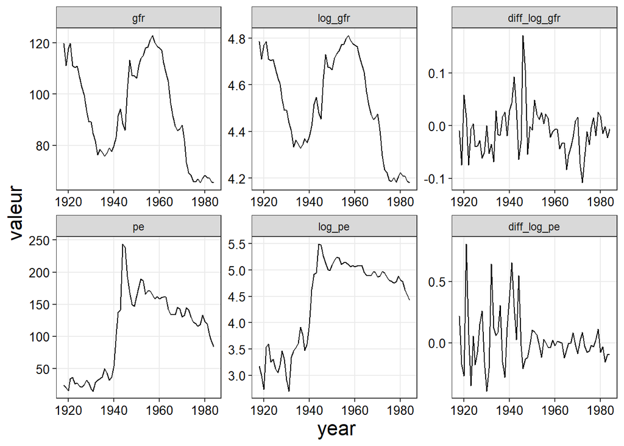

```r
df |>
  pivot_longer(
    cols = !c(year, pill, ww2),
    names_to = "nom",
    values_to = "valeur"
  ) |>
  mutate(
    nom = factor(nom, levels = c("gfr", "log_gfr", "diff_log_gfr", "pe", "log_pe", "diff_log_pe"))
  ) |>
  ggplot(aes(x = year, y = valeur)) +
  geom_line() +
  facet_wrap("nom", scales=  "free")
```

```r
df_ts <-
  df |>
  timetk::tk_zooreg(
    select = !year,
    start = df$year[1] |>  year(),
    frequency = 1
  )

head(df_ts)
```

```
       gfr    pe pill ww2  log_gfr   log_pe diff_log_gfr diff_log_pe
1918 119.8 23.94    0   0 4.785824 3.175551 -0.009966834   0.2170012
1919 111.2 20.07    0   0 4.711330 2.999226 -0.074493357  -0.1763246
1920 117.9 15.33    0   0 4.769837 2.729812  0.058506466  -0.2694145
1921 119.8 34.32    0   0 4.785824 3.535728  0.015986891   0.8059166
1922 111.2 36.65    0   0 4.711330 3.601413 -0.074493357   0.0656852
1923 110.5 25.83    0   0 4.705016 3.251537 -0.006314833  -0.3498769
```

```r
urca::ur.df(df$log_gfr, "trend", lags = 20, selectlags = "AIC") |>
  summary()
```

```
###############################################
# Augmented Dickey-Fuller Test Unit Root Test #
###############################################

Test regression trend


Call:
lm(formula = z.diff ~ z.lag.1 + 1 + tt + z.diff.lag)

Residuals:
      Min        1Q    Median        3Q       Max
-0.066296 -0.024084  0.002171  0.023550  0.123953

Coefficients:
             Estimate Std. Error t value Pr(>|t|)
(Intercept)  0.345161   0.159414   2.165  0.03640 *
z.lag.1     -0.062428   0.032269  -1.935  0.06014 .
tt          -0.001536   0.000596  -2.576  0.01378 *
z.diff.lag1  0.507677   0.149127   3.404  0.00152 **
z.diff.lag2 -0.476835   0.150441  -3.170  0.00293 **
z.diff.lag3  0.213956   0.148141   1.444  0.15645
---
Signif. codes:  0 '***' 0.001 '**' 0.01 '*' 0.05 '.' 0.1 ' ' 1

Residual standard error: 0.03916 on 40 degrees of freedom
Multiple R-squared:  0.4223,    Adjusted R-squared:  0.3501
F-statistic: 5.848 on 5 and 40 DF,  p-value: 0.0003817


Value of test-statistic is: -1.9346 2.4844 3.6485

Critical values for test statistics:
      1pct  5pct 10pct
tau3 -4.04 -3.45 -3.15
phi2  6.50  4.88  4.16
phi3  8.73  6.49  5.47
```

```r
urca::ur.df(df$log_gfr, "drift", lags = 20, selectlags = "AIC") |>
  summary()
```

```
###############################################
# Augmented Dickey-Fuller Test Unit Root Test #
###############################################

Test regression drift


Call:
lm(formula = z.diff ~ z.lag.1 + 1 + z.diff.lag)

Residuals:
     Min       1Q   Median       3Q      Max
-0.05585 -0.02457 -0.00752  0.02520  0.13205

Coefficients:
            Estimate Std. Error t value Pr(>|t|)
(Intercept)  0.20538    0.14039   1.463 0.151507
z.lag.1     -0.04588    0.03106  -1.477 0.147623
z.diff.lag1  0.55211    0.15172   3.639 0.000792 ***
z.diff.lag2 -0.42706    0.17601  -2.426 0.019974 *
z.diff.lag3  0.35730    0.18457   1.936 0.060155 .
z.diff.lag4  0.02794    0.17506   0.160 0.874023
z.diff.lag5  0.29329    0.15744   1.863 0.070025 .
---
Signif. codes:  0 '***' 0.001 '**' 0.01 '*' 0.05 '.' 0.1 ' ' 1

Residual standard error: 0.04035 on 39 degrees of freedom
Multiple R-squared:  0.402, Adjusted R-squared:   0.31
F-statistic: 4.369 on 6 and 39 DF,  p-value: 0.00182


Value of test-statistic is: -1.4773 1.1382

Critical values for test statistics:
      1pct  5pct 10pct
tau2 -3.51 -2.89 -2.58
phi1  6.70  4.71  3.86
```

```r
urca::ur.df(df$log_gfr, "none", lags = 20, selectlags = "AIC") |>
  summary()
```

```
###############################################
# Augmented Dickey-Fuller Test Unit Root Test #
###############################################

Test regression none


Call:
lm(formula = z.diff ~ z.lag.1 - 1 + z.diff.lag)

Residuals:
      Min        1Q    Median        3Q       Max
-0.068179 -0.019933 -0.004234  0.014968  0.150982

Coefficients:
              Estimate Std. Error t value Pr(>|t|)
z.lag.1     -0.0005542  0.0013622  -0.407  0.68621
z.diff.lag1  0.6243398  0.1462812   4.268  0.00011 ***
z.diff.lag2 -0.4763187  0.1589243  -2.997  0.00456 **
z.diff.lag3  0.3128714  0.1458749   2.145  0.03780 *
---
Signif. codes:  0 '***' 0.001 '**' 0.01 '*' 0.05 '.' 0.1 ' ' 1

Residual standard error: 0.04154 on 42 degrees of freedom
Multiple R-squared:  0.3223,    Adjusted R-squared:  0.2578
F-statistic: 4.994 on 4 and 42 DF,  p-value: 0.002196


Value of test-statistic is: -0.4068

Critical values for test statistics:
     1pct  5pct 10pct
tau1 -2.6 -1.95 -1.61
```

```r
urca::ur.df(df$log_pe, "trend", lags = 20, selectlags = "AIC") |>
  summary()
```

```
###############################################
# Augmented Dickey-Fuller Test Unit Root Test #
###############################################

Test regression trend


Call:
lm(formula = z.diff ~ z.lag.1 + 1 + tt + z.diff.lag)

Residuals:
      Min        1Q    Median        3Q       Max
-0.144412 -0.049409 -0.009865  0.029167  0.194965

Coefficients:
              Estimate Std. Error t value   Pr(>|t|)
(Intercept)   1.314598   0.237152   5.543 0.00000503 ***
z.lag.1      -0.211401   0.049373  -4.282   0.000175 ***
tt           -0.005685   0.001908  -2.979   0.005687 **
z.diff.lag1   0.240831   0.134138   1.795   0.082670 .
z.diff.lag2  -0.033309   0.133387  -0.250   0.804508
z.diff.lag3   0.103594   0.120654   0.859   0.397370
z.diff.lag4  -0.186664   0.121600  -1.535   0.135247
z.diff.lag5   0.108018   0.126511   0.854   0.399973
z.diff.lag6  -0.148250   0.119611  -1.239   0.224791
z.diff.lag7  -0.210392   0.111473  -1.887   0.068817 .
z.diff.lag8   0.074421   0.090530   0.822   0.417535
z.diff.lag9   0.123085   0.090692   1.357   0.184847
z.diff.lag10 -0.031785   0.093143  -0.341   0.735294
z.diff.lag11 -0.114178   0.092077  -1.240   0.224574
z.diff.lag12  0.137761   0.092844   1.484   0.148297
z.diff.lag13 -0.202049   0.094045  -2.148   0.039873 *
---
Signif. codes:  0 '***' 0.001 '**' 0.01 '*' 0.05 '.' 0.1 ' ' 1

Residual standard error: 0.09584 on 30 degrees of freedom
Multiple R-squared:  0.7681,    Adjusted R-squared:  0.6522
F-statistic: 6.624 on 15 and 30 DF,  p-value: 0.000006003


Value of test-statistic is: -4.2817 11.7878 17.5893

Critical values for test statistics:
      1pct  5pct 10pct
tau3 -4.04 -3.45 -3.15
phi2  6.50  4.88  4.16
phi3  8.73  6.49  5.47
```

```r
urca::ur.df(df$log_pe, "drift", lags = 20, selectlags = "AIC") |>
  summary()
```

```
###############################################
# Augmented Dickey-Fuller Test Unit Root Test #
###############################################

Test regression drift


Call:
lm(formula = z.diff ~ z.lag.1 + 1 + z.diff.lag)

Residuals:
      Min        1Q    Median        3Q       Max
-0.181373 -0.061134  0.000062  0.059044  0.294933

Coefficients:
            Estimate Std. Error t value  Pr(>|t|)
(Intercept)  1.24738    0.24410   5.110 0.0000115 ***
z.lag.1     -0.25430    0.04963  -5.124 0.0000110 ***
z.diff.lag1  0.31018    0.13412   2.313    0.0267 *
z.diff.lag2  0.02953    0.13826   0.214    0.8321
z.diff.lag3  0.23517    0.12406   1.896    0.0663 .
z.diff.lag4 -0.10299    0.12641  -0.815    0.4207
z.diff.lag5  0.12871    0.12615   1.020    0.3146
z.diff.lag6 -0.11107    0.12677  -0.876    0.3869
z.diff.lag7 -0.06423    0.10963  -0.586    0.5617
z.diff.lag8  0.18862    0.09437   1.999    0.0535 .
z.diff.lag9  0.18969    0.09734   1.949    0.0594 .
---
Signif. codes:  0 '***' 0.001 '**' 0.01 '*' 0.05 '.' 0.1 ' ' 1

Residual standard error: 0.108 on 35 degrees of freedom
Multiple R-squared:  0.6564,    Adjusted R-squared:  0.5582
F-statistic: 6.686 on 10 and 35 DF,  p-value: 0.0000105


Value of test-statistic is: -5.1236 13.1255

Critical values for test statistics:
      1pct  5pct 10pct
tau2 -3.51 -2.89 -2.58
phi1  6.70  4.71  3.86
```

```r
urca::ur.df(df$log_pe, "none", lags = 20, selectlags = "AIC") |>
  summary()
```

```
###############################################
# Augmented Dickey-Fuller Test Unit Root Test #
###############################################

Test regression none


Call:
lm(formula = z.diff ~ z.lag.1 - 1 + z.diff.lag)

Residuals:
     Min       1Q   Median       3Q      Max
-0.26757 -0.06048 -0.01021  0.03256  0.52866

Coefficients:
           Estimate Std. Error t value Pr(>|t|)
z.lag.1    0.001358   0.004451   0.305  0.76174
z.diff.lag 0.434901   0.131256   3.313  0.00185 **
---
Signif. codes:  0 '***' 0.001 '**' 0.01 '*' 0.05 '.' 0.1 ' ' 1

Residual standard error: 0.1477 on 44 degrees of freedom
Multiple R-squared:  0.2057,    Adjusted R-squared:  0.1696
F-statistic: 5.697 on 2 and 44 DF,  p-value: 0.006305


Value of test-statistic is: 0.3051

Critical values for test statistics:
     1pct  5pct 10pct
tau1 -2.6 -1.95 -1.61
```

```r
lm_statique <- lm(log_gfr ~ log_pe + pill + ww2, data = df)

summary(lm_statique)
```

```
Call:
lm(formula = log_gfr ~ log_pe + pill + ww2, data = df)

Residuals:
     Min       1Q   Median       3Q      Max
-0.27429 -0.11687 -0.00896  0.09777  0.32559

Coefficients:
            Estimate Std. Error t value             Pr(>|t|)
(Intercept)  4.23016    0.10649  39.723 < 0.0000000000000002 ***
log_pe       0.09509    0.02533   3.754             0.000381 ***
pill        -0.35257    0.04355  -8.096      0.0000000000243 ***
ww2         -0.23036    0.07469  -3.084             0.003031 **
---
Signif. codes:  0 '***' 0.001 '**' 0.01 '*' 0.05 '.' 0.1 ' ' 1

Residual standard error: 0.1483 on 63 degrees of freedom
Multiple R-squared:  0.5113,    Adjusted R-squared:  0.488
F-statistic: 21.97 on 3 and 63 DF,  p-value: 0.0000000007464
```

```r
lm_ar <- dynlm::dynlm(log_gfr ~ L(log_gfr) + log_pe + pill + ww2, data = df_ts)

summary(lm_ar)
```

```
Time series regression with "zooreg" data:
Start = 1919, End = 1984

Call:
dynlm::dynlm(formula = log_gfr ~ L(log_gfr) + log_pe + pill +
    ww2, data = df_ts)

Residuals:
     Min       1Q   Median       3Q      Max
-0.08281 -0.02649 -0.00136  0.02233  0.12749

Coefficients:
             Estimate Std. Error t value             Pr(>|t|)
(Intercept)  0.387244   0.144230   2.685              0.00933 **
L(log_gfr)   0.892653   0.033087  26.979 < 0.0000000000000002 ***
log_pe       0.025479   0.007623   3.342              0.00142 **
pill        -0.066777   0.015977  -4.180            0.0000947 ***
ww2         -0.022759   0.021984  -1.035              0.30462
---
Signif. codes:  0 '***' 0.001 '**' 0.01 '*' 0.05 '.' 0.1 ' ' 1

Residual standard error: 0.04086 on 61 degrees of freedom
Multiple R-squared:  0.9631,    Adjusted R-squared:  0.9607
F-statistic: 398.1 on 4 and 61 DF,  p-value: < 0.00000000000000022
```

```r
model_selection <-
  ARDL::auto_ardl(
    log_gfr ~ log_pe | ww2 + pill,
    data = df_ts,
    max_order = 5,
    selection = "BIC"
  )

model_selection$top_orders
```

```
   log_gfr log_pe       BIC
1        3      3 -221.7543
2        2      3 -217.1013
3        3      4 -216.9120
4        1      0 -214.8433
5        4      3 -214.6643
6        4      4 -213.1556
7        1      1 -212.8469
8        2      4 -211.6981
9        2      2 -204.4353
10       5      5 -200.7002
```

```r
model <- model_selection$best_model

summary(model)
```

```
Time series regression with "zooreg" data:
Start = 1921, End = 1984

Call:
dynlm::dynlm(formula = full_formula, data = data, start = start,
    end = end)

Residuals:
      Min        1Q    Median        3Q       Max
-0.070097 -0.020754  0.000676  0.022199  0.077559

Coefficients:
               Estimate Std. Error t value            Pr(>|t|)
(Intercept)    0.347607   0.119882   2.900            0.005393 **
L(log_gfr, 1)  1.205398   0.109869  10.971 0.00000000000000232 ***
L(log_gfr, 2) -0.600023   0.157120  -3.819            0.000348 ***
L(log_gfr, 3)  0.290663   0.102951   2.823            0.006642 **
log_pe         0.031546   0.024540   1.285            0.204120
L(log_pe, 1)  -0.006867   0.031203  -0.220            0.826636
L(log_pe, 2)   0.077847   0.031029   2.509            0.015148 *
L(log_pe, 3)  -0.072247   0.023639  -3.056            0.003480 **
ww2           -0.040153   0.023030  -1.743            0.086938 .
pill          -0.063087   0.014505  -4.349 0.00006093999116124 ***
---
Signif. codes:  0 '***' 0.001 '**' 0.01 '*' 0.05 '.' 0.1 ' ' 1

Residual standard error: 0.03259 on 54 degrees of freedom
Multiple R-squared:  0.9784,    Adjusted R-squared:  0.9748
F-statistic: 271.5 on 9 and 54 DF,  p-value: < 0.00000000000000022
```

```r
uecm_model <- ARDL::uecm(model)

summary(uecm_model)
```

```
Time series regression with "zooreg" data:
Start = 1921, End = 1984

Call:
dynlm::dynlm(formula = full_formula, data = data, start = start,
    end = end)

Residuals:
      Min        1Q    Median        3Q       Max
-0.070097 -0.020754  0.000676  0.022199  0.077559

Coefficients:
                  Estimate Std. Error t value  Pr(>|t|)
(Intercept)       0.347607   0.119882   2.900  0.005393 **
L(log_gfr, 1)    -0.103962   0.028118  -3.697  0.000511 ***
L(log_pe, 1)      0.030279   0.007151   4.234 0.0000897 ***
d(L(log_gfr, 1))  0.309360   0.103443   2.991  0.004187 **
d(L(log_gfr, 2)) -0.290663   0.102951  -2.823  0.006642 **
d(log_pe)         0.031546   0.024540   1.285  0.204120
d(L(log_pe, 1))  -0.005600   0.022250  -0.252  0.802232
d(L(log_pe, 2))   0.072247   0.023639   3.056  0.003480 **
ww2              -0.040153   0.023030  -1.743  0.086938 .
pill             -0.063087   0.014505  -4.349 0.0000609 ***
---
Signif. codes:  0 '***' 0.001 '**' 0.01 '*' 0.05 '.' 0.1 ' ' 1

Residual standard error: 0.03259 on 54 degrees of freedom
Multiple R-squared:  0.5541,    Adjusted R-squared:  0.4798
F-statistic: 7.457 on 9 and 54 DF,  p-value: 0.0000005507
```

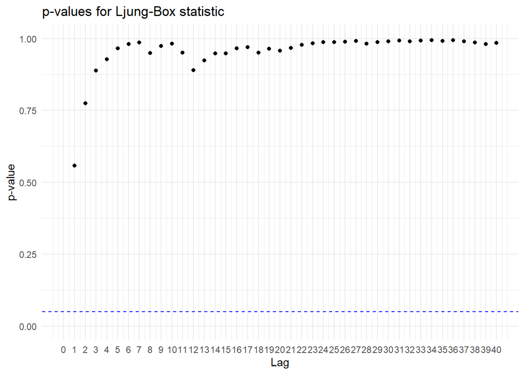

```r
LSTS::Box.Ljung.Test(uecm_model$residuals, lag = 40)
```

```r
jarque.test(as.numeric(uecm_model$residuals))
```

```
    Jarque-Bera Normality Test

data:  as.numeric(uecm_model$residuals)
JB = 0.14977, p-value = 0.9279
alternative hypothesis: greater
```

```r
lmtest::bptest(uecm_model)
```

```
    studentized Breusch-Pagan test

data:  uecm_model
BP = 13.072, df = 9, p-value = 0.1594
```

```r
whitestrap::white_test(uecm_model)
```

```
White's test results

Null hypothesis: Homoskedasticity of the residuals
Alternative hypothesis: Heteroskedasticity of the residuals
Test Statistic: 8.69
P-value: 0.012945
```

```r
fDMA::archtest(as.numeric(uecm_model$residuals**2), lag = 20)
```

```
    Engle's LM ARCH Test

data:  as.numeric(uecm_model$residuals^2)
statistic = 16.389, lag = 20, p-value = 0.6922
alternative hypothesis: ARCH effects of order 20 are present
```

```r
bounds_f_test(uecm_model, case = 2, alpha = 0.05)[["tab"]]
```

```
  statistic Lower-bound I(0) Upper-bound I(1) alpha      p.value
F  7.630195         3.620887         4.135148  0.05 0.0009516391
```

```r
bounds_t_test(uecm_model, case = 3, alpha = 0.05)[["tab"]]
```

```
  statistic Lower-bound I(0) Upper-bound I(1) alpha    p.value
t -3.697361        -2.860562        -3.224002  0.05 0.01465199
```

```r
multipliers(model)
```

```
         Term Estimate Std. Error  t value             Pr(>|t|)
1 (Intercept) 3.343593  0.3438624 9.723637 0.000000000000182664
2      log_pe 0.291247  0.0786929 3.701058 0.000504920857463079
```

```r
multipliers(model, type = "sr")
```

```
         Term    Estimate Std. Error   t value    Pr(>|t|)
1 (Intercept)  0.34760704 0.11988194  2.899578 0.005392771
2      log_pe  0.03154554 0.02454042  1.285453 0.204119844
3         ww2 -0.04015317 0.02303021 -1.743500 0.086937561
```

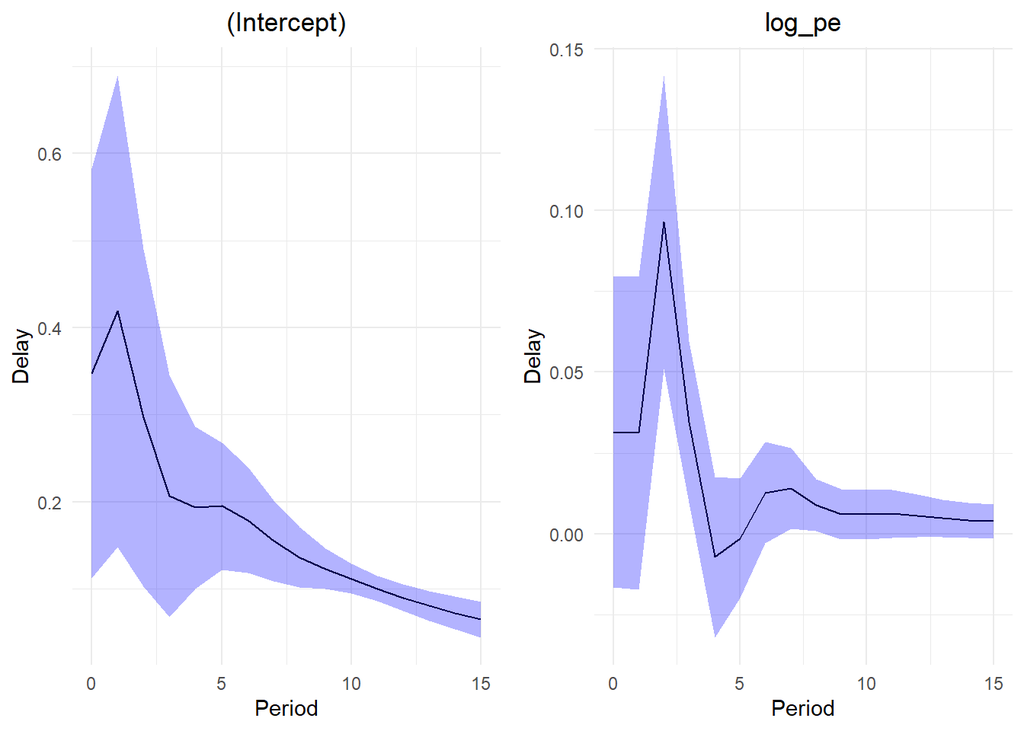

```r
ARDL::multipliers(
  model,
  type = 15,
  se = TRUE
) |>
  ARDL::plot_delay(interval = 0.95)
```

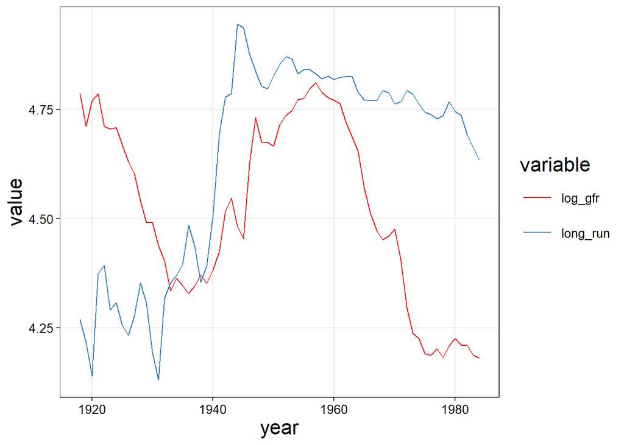

```r
long_run_eq <- ARDL::coint_eq(model, case = 2)

tibble(
  log_gfr = as.numeric(model$data$log_gfr),
  long_run = as.numeric(long_run_eq),
  year = time(model$data)
) |>
  pivot_longer(
    cols = !year,
    names_to = "variable",
    values_to = "value"
  ) |>
  ggplot(aes(x = year, y = value, color = variable)) +
  geom_line() +
  scale_color_brewer(palette = "Set1")
```

```r
recm_model <- recm(model, case = 3)

summary(recm_model)
```

```
Time series regression with "zooreg" data:
Start = 1921, End = 1984

Call:
dynlm::dynlm(formula = full_formula, data = data, start = start,
    end = end)

Residuals:
      Min        1Q    Median        3Q       Max
-0.070097 -0.020754  0.000676  0.022199  0.077559

Coefficients:
                 Estimate Std. Error t value  Pr(>|t|)
(Intercept)       0.34761    0.07439   4.672 0.0000196 ***
d(L(log_gfr, 1))  0.30936    0.10189   3.036   0.00366 **
d(L(log_gfr, 2)) -0.29066    0.09979  -2.913   0.00517 **
d(log_pe)         0.03155    0.02386   1.322   0.19161
d(L(log_pe, 1))  -0.00560    0.02204  -0.254   0.80036
d(L(log_pe, 2))   0.07225    0.02339   3.089   0.00315 **
ww2              -0.04015    0.02282  -1.760   0.08403 .
pill             -0.06309    0.01426  -4.423 0.0000464 ***
ect              -0.10396    0.02190  -4.748 0.0000151 ***
---
Signif. codes:  0 '***' 0.001 '**' 0.01 '*' 0.05 '.' 0.1 ' ' 1

Residual standard error: 0.03229 on 55 degrees of freedom
  (0 observation effacée parce que manquante)
Multiple R-squared:  0.5541,    Adjusted R-squared:  0.4893
F-statistic: 8.544 on 8 and 55 DF,  p-value: 0.0000001788
```